# Vectorized Computing

November 29, 2017

## Contents

- Why?
- What & How?
- Experiments on performance

## MIMD or SIMD?

| Technique | Pursuing | Blocked by |
| --- | --- | --- |
| SISD | Higher speed (GHz) | Physics |
| MIMD | More CPU cores | Synchronization |
| SIMD | More CUDA cores | Price :) |

## CPU or GPU?

| Technique | Instruction | Vector length |
| --- | --- | --- |
| CPU SIMD | SSE4.1 SSE4.2 AVX AVX2 FMA | Commonly <= 256 bit |
| GPU SIMD | N/A, use CUDA | Thousands of Bytes |

## Programming

| Technique | Hard mode | Easy mode |
| --- | --- | --- |
| CPU SIMD | C/C++, assembly; instruction-orientated | NumPy |
| CPU MIMD | Java, etc; dead lock, data race | Java actor, Go, Rust |
| GPU SIMD | CUDA; register-orientated | ??? |

## GPU SIMD easy mode?

### Is there a GPU backend for Numpy? Money is no issue

On [Reddit](https://www.reddit.com/r/Python/comments/1mw9mb/is_there_a_gpu_backend_for_numpyscipy_money_is_no/), four years ago.

- PyCUDA and PyOpenCL: Register-orientated :(
- NumbaPro: Register-orientated :(
- Theano: Died now :(
- gnumpy: Only a small subset of NumPy; Died now :(
- Currently, PyTorch is free for everyone.
- PyTorch feature: Tensor computation (like NumPy) with strong GPU acceleration.

## Distributed programming

- Target: balance on Consistency, Availability and Partition tolerance
- MapReduce, by Google, in 2004
- Hadoop (fair mode), Spark (easy mode)
- MPI (hard mode)

## Matrix multiplication

### A = BxC

```python
for i in range(m):
  for j in range(n):
    for k in range(r):
      A[i][j] += B[i][k] * C[k][j]
```

## Matrix multiplication

### Vectorized

```python
for i in range(m):
  for j in range(n):
    A[i, j] = np.sum(B[i, :] * C[:, j])
```

```python
for i in range(m):
  for j in range(n):
    for k in range(r):
      A[i][j] += B[i][k] * C[k][j]
```

## Matrix multiplication

### Fully vectorized

```python
m_r_n = B.reshape(m, r, 1) * C.reshape(1, r, n)
A = np.sum(m_r_n, axis=1)
```

```python
for i in range(m):
  for j in range(n):
    for k in range(r):
      A[i][j] += B[i][k] * C[k][j]
```

## Boardcasting

```python
import numpy as np
B = np.array([[0, 1]])  # shape: 1x2
C = np.array([[0],
              [1],
              [2]])  # shape: 3x1
A = B + C
print(A)
```

```
## [[0 1]
##  [1 2]
##  [2 3]]
```

## Floyd-Warshall algorithm

G is an nxn adjacency matrix

```python
for k in range(n):
  for i in range(n):
    for j in range(n):
      G[i][j] = min(G[i][j], G[i][k] + G[k][j])
```

## Floyd-Warshall algorithm

### Vectorized

```python
for k in range(n):
  n_n = G[:, k].reshape(n, 1) + G[k, :].reshape(1, n)
  G = np.minimum(G, n_n)
```

```python
for k in range(n):
  for i in range(n):
    for j in range(n):
      G[i][j] = min(G[i][j], G[i][k] + G[k][j])
```

## Experiments

```python
n = int(sys.argv[1])

g = [[random.random() for _ in range(n)] for _ in range(n)]
floyd(g, n)  # warm up

g = [[random.random() for _ in range(n)] for _ in range(n)]
tic = time.time()
floyd(g, n)
toc = time.time()

print(toc - tic)
```

## Floyd-Warshall algorithm

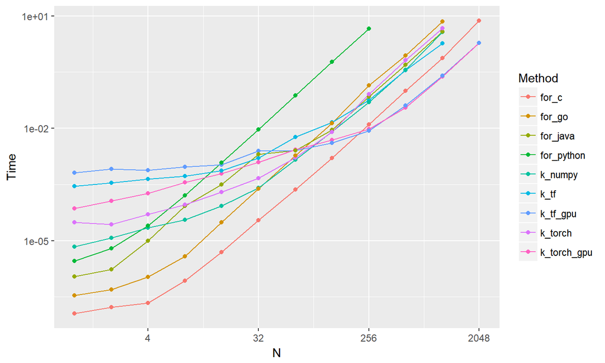

## for

### for_python << for_go < for_java < for_c

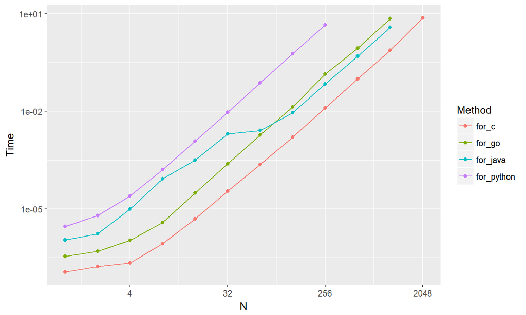

## k_cpu

### k_numpy = k_tf = k_torch = for_java < for_c

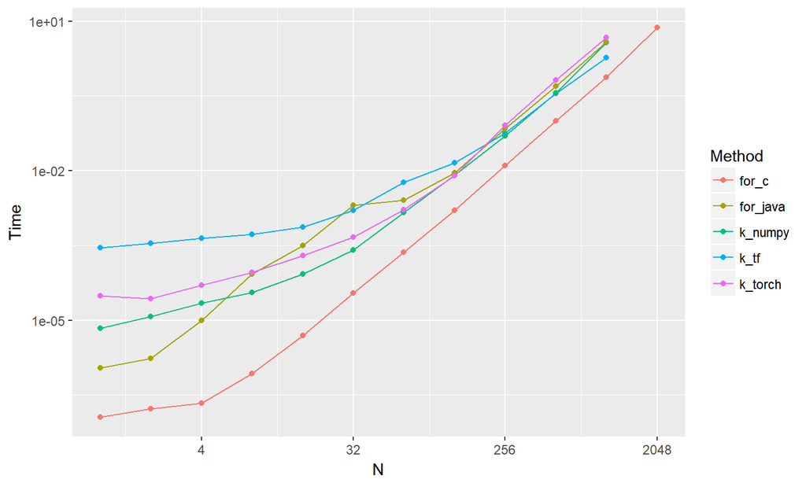

## k_gpu

### for_java < for_c < k_tf_gpu = k_torch_gpu

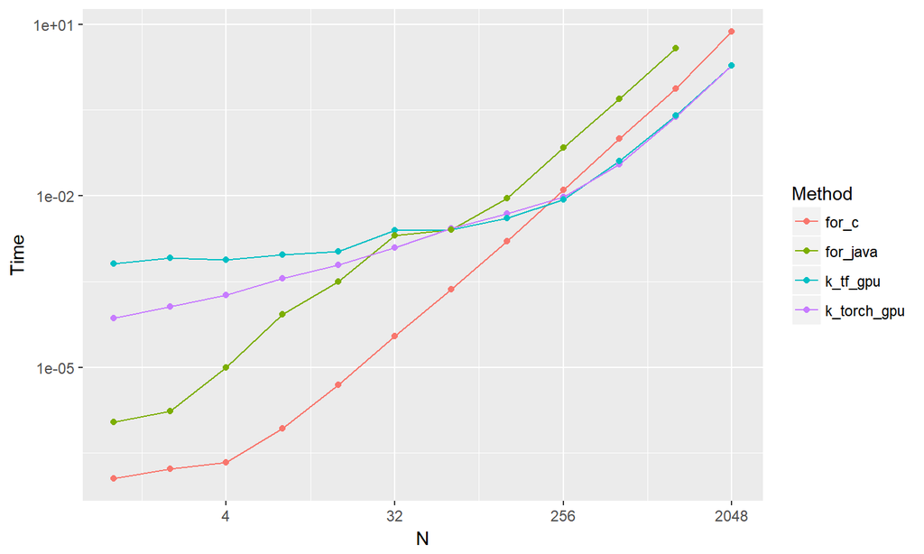

## Matrix multiplication

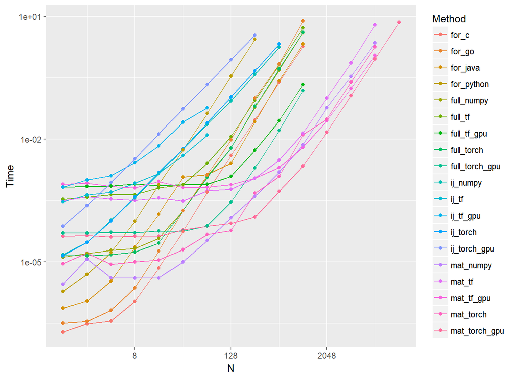

## for

### for_python << for_go < for_java <= for_c

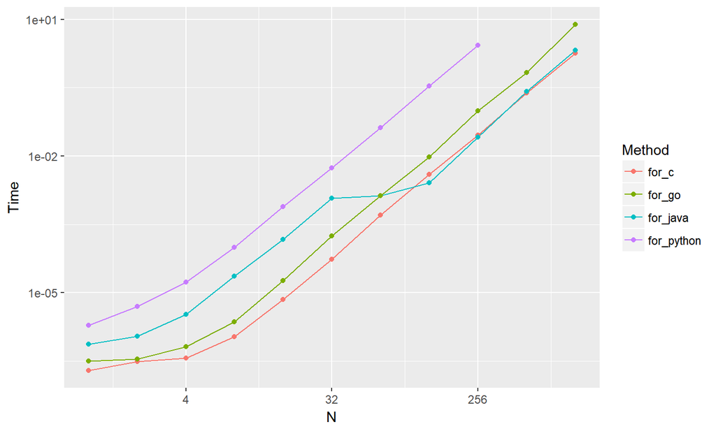

## ij

### ij_*_gpu < ij_cpu < for_+

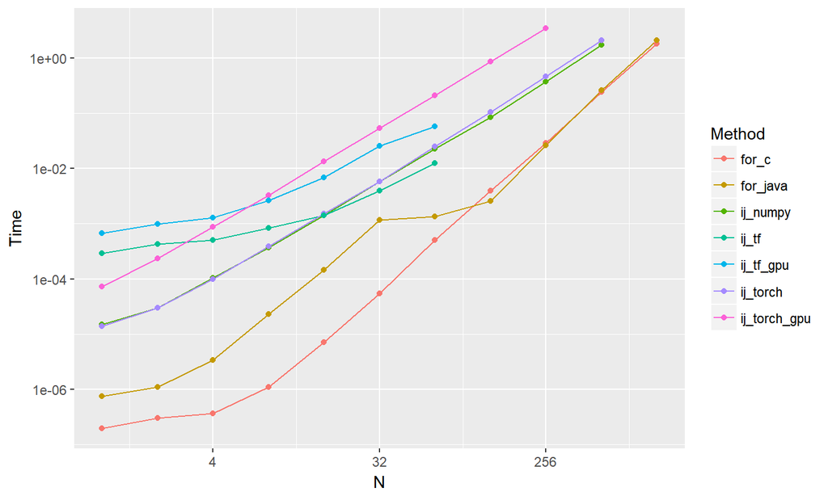

## full

### full_cpu < for_+ < full_tf_gpu < full_torch_gpu

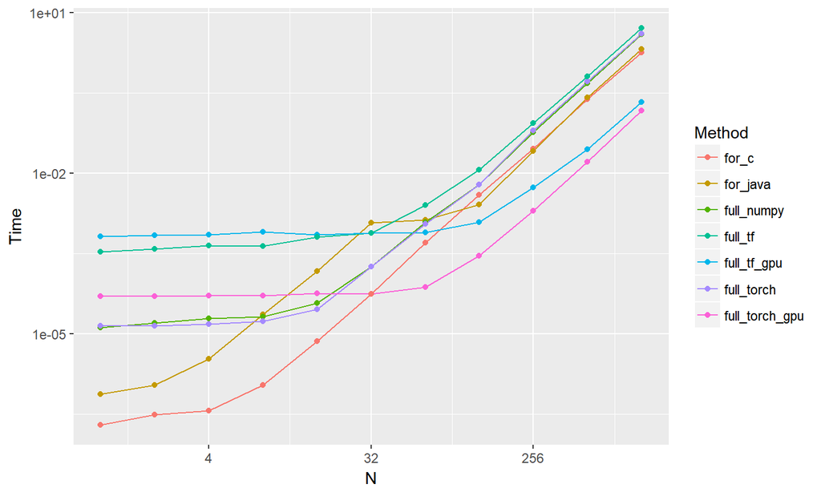

## mat

### for_+ < full_*_gpu < mat_*

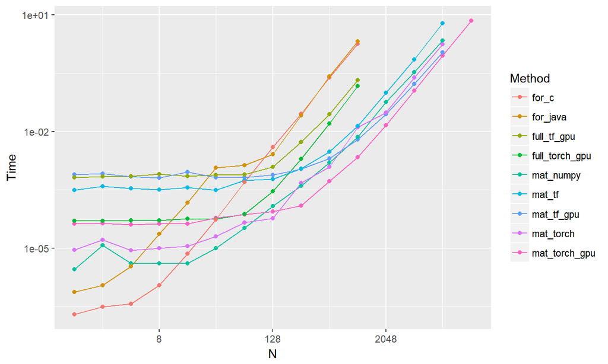

## mat only

### tf < numpy < torch < tf_gpu < torch_gpu (mat_)

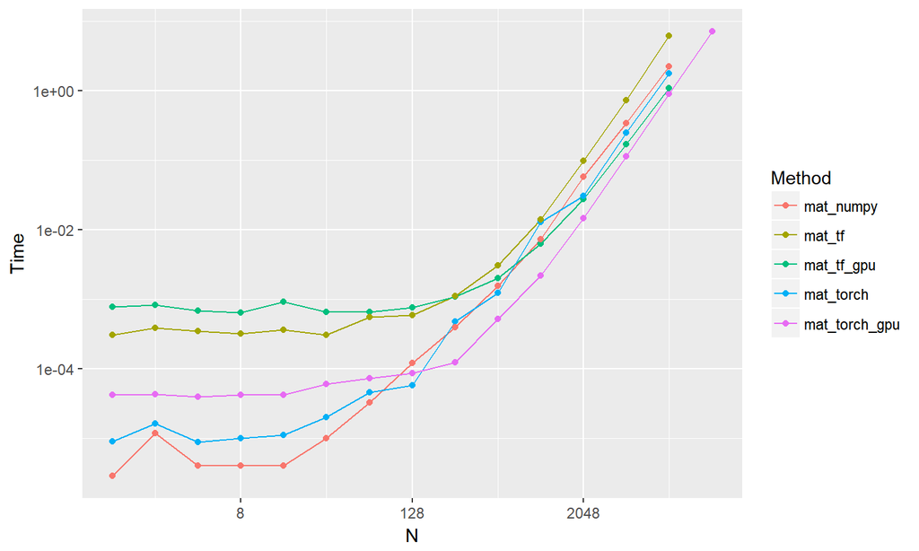

## Issue #1408 · tensorflow/tensorflow

### Generalized matrix multiplication with semiring?

> Closing since I think this is out of reach of easy contributions. A trivial implementation is trivial, but users are likely to want fast versions that are hard to write. – Geoffrey Irving at @openai

https://github.com/tensorflow/tensorflow/issues/1408

## Summary

### Floyd-Warshall algorithm

- for | for_python << for_go < for_java < for_c
- k_cpu | k_numpy = k_tf = k_torch = for_java < for_c
- k_gpu | for_java < for_c < k_tf_gpu = k_torch_gpu
- I.e.
- for_python << for_go < k_numpy = k_tf = k_torch = for_java < for_c < k_tf_gpu = k_torch_gpu
- I.e.
- for_python << for_go < k_cpu = for_java < for_c < k_gpu

## Summary

### Matrix multiplication

- for | for_python << for_go < for_java <= for_c
- ij | ij_*_gpu < ij_cpu < for_+
- full | full_cpu < for_+ < full_tf_gpu < full_torch_gpu
- mat | for_+ < full_*_gpu < mat_*
- I.e.
- ij_gpu < ij_cpu < full_cpu < for_java <= for_c < full_tf_gpu < full_torch_gpu < mat_cpu < mat_gpu
- I.e.
- ij < full_cpu < for_java/c < full_gpu < mat_*

## Conclusion

- for_python << for_go < k_cpu = for_java < for_c < k_gpu
- ij < full_cpu < for_java/c < full_gpu < mat_*
- ij hurts
- Fully-vectorized gpu code, or java/c
- The code is available
- at https://github.com/meijun/vectorized-computing